# 4th Floor Fantasy Draft 2025

Evan Oman

September 1, 2025

## Introduction

This document looks at how our league handled the 2025 Fantasy Football Draft. We have drafted without cheatsheets since 2016, so every manager has to arrive with their own plan. That setup leads to big swings in pick quality, which makes the draft a fun case study each year.

Throughout the analysis I use the ESPN Superflex PPR rankings as a proxy for player value. The list is far from perfect, but it serves as a consistent yardstick for comparing draft decisions.

Source code and data live at https://github.com/EvanOman/FantasyFootball, and you can reach me via http://www.evanoman.com.

Let the fun begin!

## Data Preparation

First we load the draft data. This year I copied the ESPN draft board and reshaped it with a few regular expressions.

Load the data:

```r
draftData <- read.csv("./data/Draft2025.csv", stringsAsFactors = FALSE)

# Align column names with the rest of the workflow
names(draftData)[names(draftData) == "OverallPick"] <- "PickNumber"
names(draftData)[names(draftData) == "Position"] <- "Pos"
names(draftData)[names(draftData) == "FantasyTeam"] <- "Drafter"

print.data.frame(head(draftData), row.names = FALSE)
```

```
##  PickNumber Round PickInRound              Player NFLTeam Pos                      Drafter
##           1     1           1          Josh Allen     Buf  QB                 Purple Reign
##           2     1           2    Justin Jefferson     Min  WR              Nordick Bishops
##           3     1           3      Saquon Barkley     Phi  RB (north) Korean Fried Chicken
##           4     1           4 Christian McCaffrey      SF  RB                    FAUGENDAZ
##           5     1           5       Lamar Jackson     Bal  QB          🏈🚌 Magic Skol Bus
##           6     1           6      Bijan Robinson     Atl  RB                   Think Tank
```

The file is already in the tall format we need, so we can move straight to the rankings.

```r
rankings <- read.csv("./data/espn_superflex_ppr_2025.csv", stringsAsFactors = FALSE)

# Keep positional labels from the rankings distinct from the draft data
names(rankings)[names(rankings) == "Pos"] <- "RankPos"

# Read player as string, not factor
rankings$Player <- as.character(rankings$Player)

print.data.frame(head(rankings, n=10), row.names=FALSE)
```

```
##  Rank RankPos PositionalRank           Player Team Salary Bye
##     1      QB              1       Josh Allen  BUF     59   7
##     2      QB              2    Lamar Jackson  BAL     58   7
##     3      QB              3   Jayden Daniels  WAS     58  12
##     4      QB              4      Jalen Hurts  PHI     57   9
##     5      QB              5       Joe Burrow  CIN     57  10
##     6      WR              1    Ja'Marr Chase  CIN     55  10
##     7      RB              1   Bijan Robinson  ATL     53   5
##     8      WR              2 Justin Jefferson  MIN     51   6
##     9      RB              2   Saquon Barkley  PHI     49   9
##    10      RB              3     Jahmyr Gibbs  DET     48   8
```

```r
library("dplyr")
library("DT")

# Join rankings data with draft data
joinedData <- left_join(draftData, rankings, by="Player")

# Some players will not have a  ranking, give these players a worst ranking + 1
joinedData$Rank[is.na(joinedData$Rank)] <- nrow(rankings) + 1

print.data.frame(head(joinedData, n=10), row.names=FALSE)
```

```
##  PickNumber Round PickInRound              Player NFLTeam Pos                      Drafter Rank
##           1     1           1          Josh Allen     Buf  QB                 Purple Reign    1
##           2     1           2    Justin Jefferson     Min  WR              Nordick Bishops    8
##           3     1           3      Saquon Barkley     Phi  RB (north) Korean Fried Chicken    9
##           4     1           4 Christian McCaffrey      SF  RB                    FAUGENDAZ   12
##           5     1           5       Lamar Jackson     Bal  QB          🏈🚌 Magic Skol Bus    2
##           6     1           6      Bijan Robinson     Atl  RB                   Think Tank    7
##           7     1           7      Jayden Daniels     Wsh  QB                Clint Billton    3
##           8     1           8       Ja'Marr Chase     Cin  WR    Make Loveland, Not Warren    6
##           9     2           1         CeeDee Lamb     Dal  WR    Make Loveland, Not Warren   11
##          10     2           2     Patrick Mahomes      KC  QB                Clint Billton   17
##  RankPos PositionalRank Team Salary Bye
##       QB              1  BUF     59   7
##       WR              2  MIN     51   6
##       RB              2  PHI     49   9
##       RB              4   SF     44  14
##       QB              2  BAL     58   7
##       RB              1  ATL     53   5
##       QB              3  WAS     58  12
##       WR              1  CIN     55  10
##       WR              3  DAL     46  10
##       QB              6   KC     38  10
```

The result contains every pick, its pick number, and the ESPN ranking. From here we can measure pick quality using the difference between those two numbers.

```r
joinedData$RankDiff <- joinedData$Rank - joinedData$PickNumber

print.data.frame(head(joinedData, n=10), row.names=FALSE)
```

```
##  PickNumber Round PickInRound              Player NFLTeam Pos                      Drafter Rank
##           1     1           1          Josh Allen     Buf  QB                 Purple Reign    1
##           2     1           2    Justin Jefferson     Min  WR              Nordick Bishops    8
##           3     1           3      Saquon Barkley     Phi  RB (north) Korean Fried Chicken    9
##           4     1           4 Christian McCaffrey      SF  RB                    FAUGENDAZ   12
##           5     1           5       Lamar Jackson     Bal  QB          🏈🚌 Magic Skol Bus    2
##           6     1           6      Bijan Robinson     Atl  RB                   Think Tank    7
##           7     1           7      Jayden Daniels     Wsh  QB                Clint Billton    3
##           8     1           8       Ja'Marr Chase     Cin  WR    Make Loveland, Not Warren    6
##           9     2           1         CeeDee Lamb     Dal  WR    Make Loveland, Not Warren   11
##          10     2           2     Patrick Mahomes      KC  QB                Clint Billton   17
##  RankPos PositionalRank Team Salary Bye RankDiff
##       QB              1  BUF     59   7        0
##       WR              2  MIN     51   6        6
##       RB              2  PHI     49   9        6
##       RB              4   SF     44  14        8
##       QB              2  BAL     58   7       -3
##       RB              1  ATL     53   5        1
##       QB              3  WAS     58  12       -4
##       WR              1  CIN     55  10       -2
##       WR              3  DAL     46  10        2
##       QB              6   KC     38  10        7
```

With the data prepped we can move on to summarizing the draft.

## Figures and Results

A natural starting point is the average difference between pick number and rank for each drafter. We calculate that with `aggregate`.

```r
avgDiffs <- aggregate(RankDiff ~ Drafter, joinedData, FUN=mean)

# Order factor by worst draft to best
avgDiffs <- within(avgDiffs, Drafter <- factor(Drafter, levels=avgDiffs[order(avgDiffs$RankDiff), "Drafter"]))

# Order dataframe by worst draft to best
avgDiffs <- avgDiffs[order(avgDiffs$RankDiff, decreasing = FALSE),]

print.data.frame(avgDiffs, row.names=FALSE)
```

```
##                       Drafter RankDiff
##                    Think Tank  -2.7500
##     Make Loveland, Not Warren   1.2500
##                  Purple Reign   2.6875
##                 Clint Billton   7.4375
##  (north) Korean Fried Chicken  35.1875
##           🏈🚌 Magic Skol Bus  40.5625
##                     FAUGENDAZ  55.0000
##               Nordick Bishops  78.9375
```

From this table we learn that Think Tank landed the strongest class (his average pick was 2.75 slots under the ESPN rank) while Nordick Bishops struggled the most (averaging 78.9375 spots over). The bar chart below gives the same view at a glance.

[figure not shown]

```r
library(ggplot2)
ggplot(avgDiffs, aes(x=Drafter, y=RankDiff)) + geom_bar(stat = "identity") + ylab("Mean Difference Between Pick # and Ranking")
```

```r
noKorDst <- joinedData[!(joinedData$Pos %in% c("DST", "K")), ]

avgDiffs2 <- aggregate(RankDiff ~ Drafter, noKorDst, FUN=mean)

# Order factor by worst draft to best
avgDiffs2 <- within(avgDiffs2, Drafter <- factor(Drafter, levels=avgDiffs[order(avgDiffs$RankDiff), "Drafter"]))

# Order dataframe by worst draft to best
avgDiffs2 <- avgDiffs2[order(avgDiffs2$RankDiff, decreasing = FALSE),]

print.data.frame(avgDiffs2, row.names=FALSE)
```

```
##                       Drafter   RankDiff
##                    Think Tank -14.466667
##                  Purple Reign  -8.400000
##     Make Loveland, Not Warren  -2.866667
##                 Clint Billton   3.733333
##  (north) Korean Fried Chicken  25.733333
##           🏈🚌 Magic Skol Bus  31.400000
##                     FAUGENDAZ  53.666667
##               Nordick Bishops  79.933333
```

Next I look at positional trends to see which spots were over- or undervalued.

```r
posDiffs <- aggregate(RankDiff ~ Pos, joinedData, FUN=mean)

posDiffs <- within(posDiffs, Pos <- factor(Pos, levels=posDiffs[order(posDiffs$RankDiff), "Pos"]))

# Order dataframe by worst draft to best
posDiffs <- posDiffs[order(posDiffs$RankDiff, decreasing = FALSE),]

print.data.frame(posDiffs, row.names=FALSE)
```

```
##   Pos   RankDiff
##    QB  -1.190476
##    WR  13.232558
##    RB  15.361111
##    TE  66.666667
##  D/ST  79.250000
##     K 120.250000
```

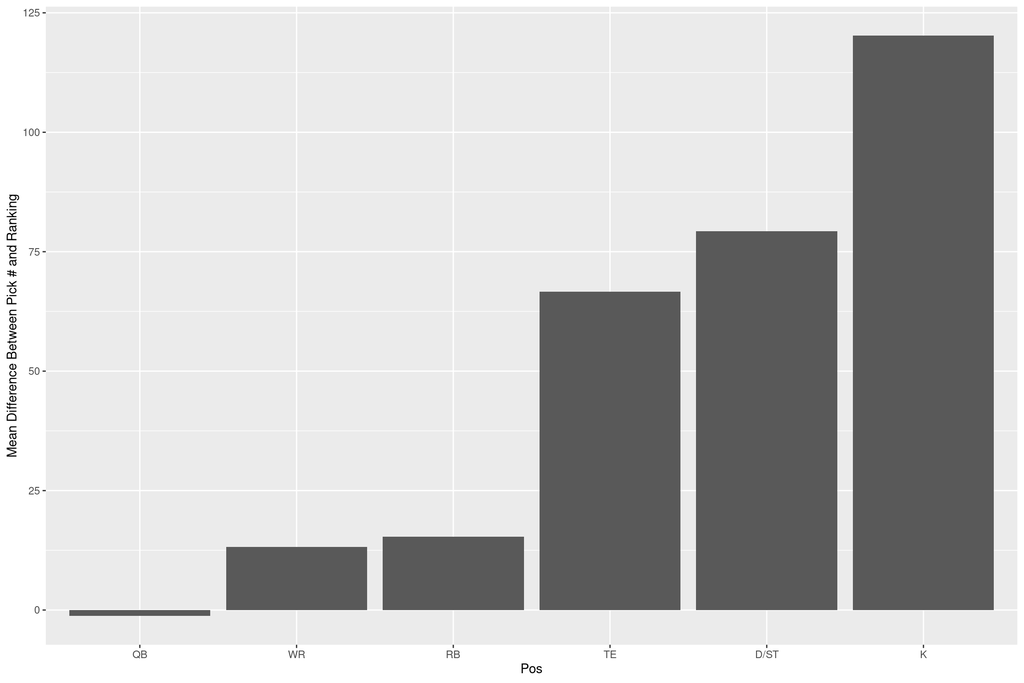

```r
ggplot(posDiffs, aes(x=Pos, y=RankDiff)) + geom_bar(stat = "identity") + ylab("Mean Difference Between Pick # and Ranking")
```

The chart shows that QB were under valued by 1.1904762 picks on average, while K were over valued by 120.25 picks.

Draft quality definitely decays over time, so the next two plots chart `Pick #` versus `Rank` with a diagonal “break-even” line. Points below the line were bargains; points above were reaches. The first plot highlights drafters and the second highlights positions.

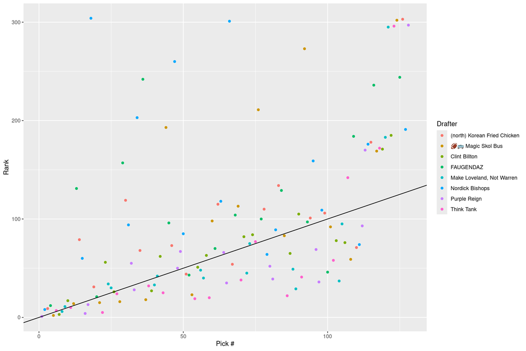

```r
# Scatter colored by drafter
ggplot(joinedData, aes(x=PickNumber,y=Rank)) + geom_point(aes(color=Drafter)) + geom_abline() + xlab("Pick #")
```

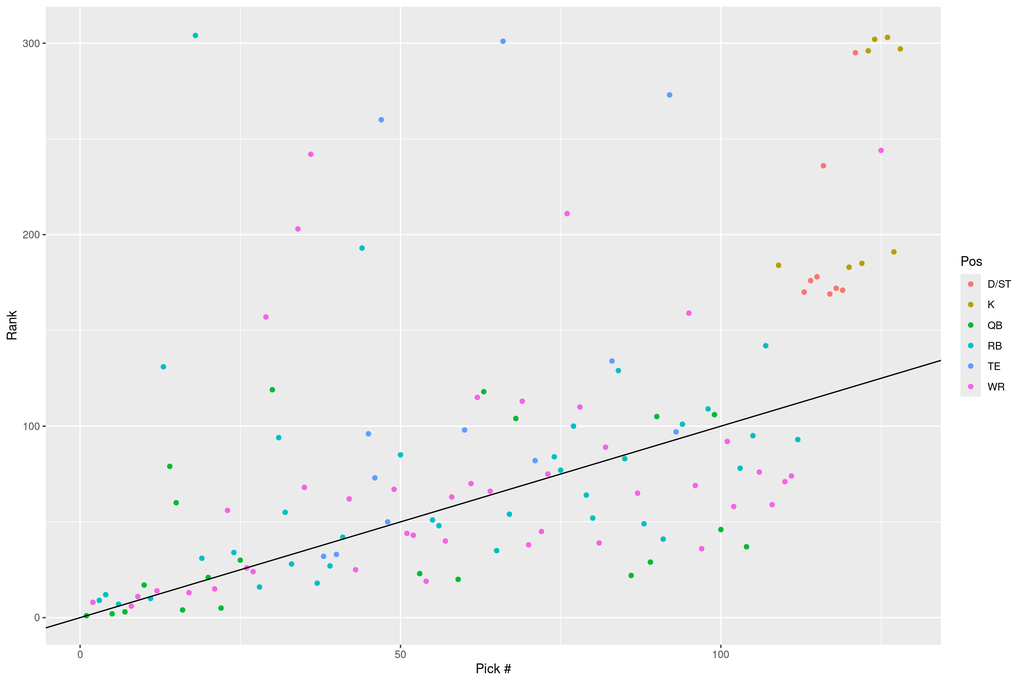

```r
# Scatter colored by position
ggplot(joinedData, aes(x=PickNumber,y=Rank)) + geom_point(aes(color=Pos)) + geom_abline() + xlab("Pick #")
```

Both plots make it clear that the later rounds are a free-for-all.

Finally, I look at the round-by-round swings for each drafter. In the figure below, anything below the dashed line is a win and anything above is a reach.

[figure not shown]

```r
# Scatter colored by position, faceted by drafter
ggplot(joinedData, aes(x=Round, y=RankDiff)) + geom_line() + facet_wrap(~Drafter, ncol=2) + geom_hline(yintercept = 0, linetype=2) + geom_point(aes(color=Pos)) + ylab("Difference Between Pick # and Ranking")
```

## Conclusion

Here are the key takeaways:

- **Best Draft:** Think Tank (avg pick 2.75 positions under rank value)
- **Worst Draft:** Nordick Bishops (avg pick 78.9375 positions over rank value)
- **Best Pick:** Drafter: Make Loveland, Not Warren, Round: 13, Player: Drake Maye, Rank Difference: -67
- **Worst Pick:** Drafter: Nordick Bishops, Round: 3, Player: Tahj Brooks, Rank Difference: 286

## Pick Ledger

```r
rawTable <- joinedData[order(joinedData$PickNumber), c("PickNumber", "Round", "Drafter", "Player", "Rank", "RankDiff")]

datatable(
  rawTable,
  colnames = c("Pick #", "Round", "Team", "Player", "ESPN Rank", "Rank Diff"),
  filter = "top",
  options = list(pageLength = 25, autoWidth = TRUE)
)
```

|  | Pick # | Round | Team | Player | ESPN Rank | Rank Diff |
| --- | --- | --- | --- | --- | --- | --- |
| 1 | 1 | 1 | Purple Reign | Josh Allen | 1 | 0 |
| 2 | 2 | 1 | Nordick Bishops | Justin Jefferson | 8 | 6 |
| 3 | 3 | 1 | (north) Korean Fried Chicken | Saquon Barkley | 9 | 6 |
| 4 | 4 | 1 | FAUGENDAZ | Christian McCaffrey | 12 | 8 |
| 5 | 5 | 1 | 🏈🚌 Magic Skol Bus | Lamar Jackson | 2 | -3 |
| 6 | 6 | 1 | Think Tank | Bijan Robinson | 7 | 1 |
| 7 | 7 | 1 | Clint Billton | Jayden Daniels | 3 | -4 |
| 8 | 8 | 1 | Make Loveland, Not Warren | Ja'Marr Chase | 6 | -2 |
| 9 | 9 | 2 | Make Loveland, Not Warren | CeeDee Lamb | 11 | 2 |
| 10 | 10 | 2 | Clint Billton | Patrick Mahomes | 17 | 7 |

[output cut: 118 more lines]